## Исследование спортивных данных

Пример, о котором я говорила на прошлом занятии, находится по ссылке https://complementarytraining.net/playbook-exploring-decathlon-competition-data-part-1/.

Автор исследует влияние результата в разных дисциплинах десятиборья на итоговый результат. Для этого используется датасет decathlone из пакета FactoMineR

```r
# Загружаются данные
data(decathlon)

# Отбираются только результаты Олимпиады
decathlon <- subset(decathlon, Competition == "OlympicG")

# место спортсмена в соревновании добавляется в имя строки
rownames(decathlon) <- paste(1:28, rownames(decathlon))

# Исправляются названия колонок, которые начинаются с номера
names(decathlon) <- c("X100m", "Long.Jump", "Shot.Put", "High.Jump", "X400m",
    "X110m.Hurdle", "Discus", "Pole.Vault", "Javeline", "X1500m", "Rank", "Points", "Competition")

head(decathlon)
```

```
##             X100m Long.Jump Shot.Put High.Jump X400m X110m.Hurdle Discus
## 1 Sebrle    10.85      7.84    16.36      2.12 48.36        14.05  48.72
## 2 Clay      10.44      7.96    15.23      2.06 49.19        14.13  50.11
## 3 Karpov    10.50      7.81    15.93      2.09 46.81        13.97  51.65
## 4 Macey     10.89      7.47    15.73      2.15 48.97        14.56  48.34
## 5 Warners   10.62      7.74    14.48      1.97 47.97        14.01  43.73
## 6 Zsivoczky 10.91      7.14    15.31      2.12 49.40        14.95  45.62
##             Pole.Vault Javeline X1500m Rank Points Competition
## 1 Sebrle           5.0    70.52 280.01    1   8893    OlympicG
## 2 Clay             4.9    69.71 282.00    2   8820    OlympicG
## 3 Karpov           4.6    55.54 278.11    3   8725    OlympicG
## 4 Macey            4.4    58.46 265.42    4   8414    OlympicG
## 5 Warners          4.9    55.39 278.05    5   8343    OlympicG
## 6 Zsivoczky        4.7    63.45 269.54    6   8287    OlympicG
```

Вопрос, на который автор ищет ответ - какой вид больше влияет на итоговые очки? Для этого создаётся модель, в которой в качестве зависимой переменной – колонка «points», предикторы – результаты в разных видах соревнования

```r
model1 <- lm(Points ~ X100m + Long.Jump + Shot.Put + High.Jump + X400m + X110m.Hurdle +
    Discus + Pole.Vault + Javeline + X1500m, decathlon)

summary(model1)
```

```
##
## Call:
## lm(formula = Points ~ X100m + Long.Jump + Shot.Put + High.Jump +
##     X400m + X110m.Hurdle + Discus + Pole.Vault + Javeline + X1500m,
##     data = decathlon)
##
## Residuals:
##     Min      1Q  Median      3Q     Max
## -6.2955 -1.2405 -0.2172  1.3674  5.3727
##
## Coefficients:
##                Estimate Std. Error t value Pr(>|t|)
## (Intercept)  8639.55864   76.07361  113.57   <2e-16 ***
## X100m        -227.37827    4.73420  -48.03   <2e-16 ***
## Long.Jump     243.11007    3.49346   69.59   <2e-16 ***
## Shot.Put       61.53423    1.36850   44.97   <2e-16 ***
## High.Jump     897.79036   10.41079   86.24   <2e-16 ***
## X400m         -47.19203    1.10235  -42.81   <2e-16 ***
## X110m.Hurdle -121.14394    1.85427  -65.33   <2e-16 ***
## Discus         21.15343    0.30736   68.82   <2e-16 ***
## Pole.Vault    295.45775    2.63362  112.19   <2e-16 ***
## Javeline       15.09349    0.16410   91.98   <2e-16 ***
## X1500m         -6.01357    0.09897  -60.76   <2e-16 ***
## ---
## Signif. codes:  0 '***' 0.001 '**' 0.01 '*' 0.05 '.' 0.1 ' ' 1
##
## Residual standard error: 3.33 on 17 degrees of freedom
## Multiple R-squared:  0.9999, Adjusted R-squared:  0.9999
## F-statistic: 3.38e+04 on 10 and 17 DF,  p-value: < 2.2e-16
```

Как видно, модель объясняет почти всю дисперсию, ну, естественно, это же по сути должно быть справедливое суммирование результатов. каждый вид соревнований статистически значимо влияет на результат. Некоторые коэффициенты отрицательны, так как, чем меньше результат в них, тем лучше (например, бег)

Затем коэффиценты модели конвертируют в бета-коэффициенты, для того, чтобы сравнивать между собой различные виды соревнований. Так как до этого, результаты были представлены в метрических единицах - секундах, сантиметрах и т.д., и сложно сказать, как они друг относительно друга. Как нам показывает автор дальше, это то же самое, что и нормализовать данные, а затем рассчитать коэффициенты. Уберем отрицательные значения

```r
# Load package with the function to convert coeficients to beta
model1.beta.coeficients <- lm.beta(model1)

sqrt(round(model1.beta.coeficients, 2)^2)
```

```
##        X100m    Long.Jump     Shot.Put    High.Jump        X400m X110m.Hurdle
##         0.14         0.22         0.14         0.22         0.16         0.14
##       Discus   Pole.Vault     Javeline       X1500m
##         0.19         0.23         0.20         0.18
```

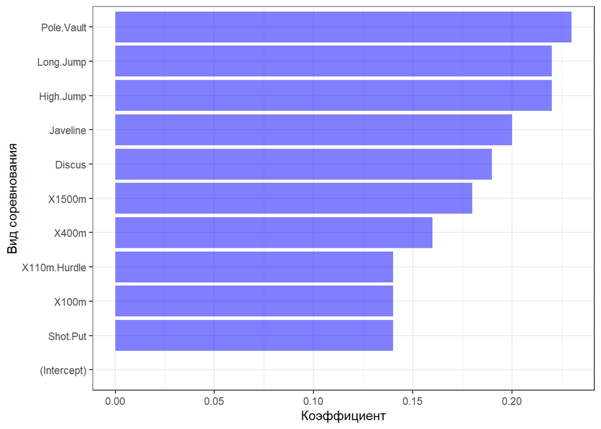

```r
n_decathlon <- decathlon %>%
  mutate_if(is.numeric, scale)

fit <- lm(Points ~ X100m + Long.Jump + Shot.Put + High.Jump + X400m + X110m.Hurdle + Discus + Pole.Vault + Javeline + X1500m, n_decathlon)

data.frame(name = names(fit$coefficients), value = sqrt(round(fit$coefficients, 2)^2)) %>%
  mutate(name = fct_reorder(name, value)) %>%
  ggplot( aes(x = name, y = value))+
    geom_bar(stat = "identity", fill = "blue", alpha = 0.5)+
  coord_flip()+
  theme_bw()+
  xlab("Вид соревнования")+
  ylab("Коэффициент")
```

Таким образом, на результат больше влияют (в порядке убывания): прыжок с шестом, прыжок в длину, прыжок в высоту, метние копья, метание диска, бег на 1500 метров, бег на 400 метров, бег 110 метров с барьерами, бег на 100 метров и толкание ядра. То есть, у этих видов соревнования статистически значимая связь с результативностью, и она тем больше, чем больше значение коэффициентов b1

можем ли мы сделать такие выводы?

Корреляционная матрица

Вот такой код выполняется в R, но в маркдаун возникает ошибка, так что просто добавлю картинку с результатом

n_decathlon <- data.frame(apply(n_decathlon, 2, as.numeric))

Создадим таблицу с уровнями значимости

testRes <- cor.mtest(data.frame(n_decathlon), conf.level = 0.95)

corrplot(cor(n_decathlon), p.mat = testRes$p, method = ‘circle’, type = ‘lower’, insig=‘blank’, addCoef.col =‘black’, number.cex = 0.8, order = ‘AOE’, diag=FALSE)

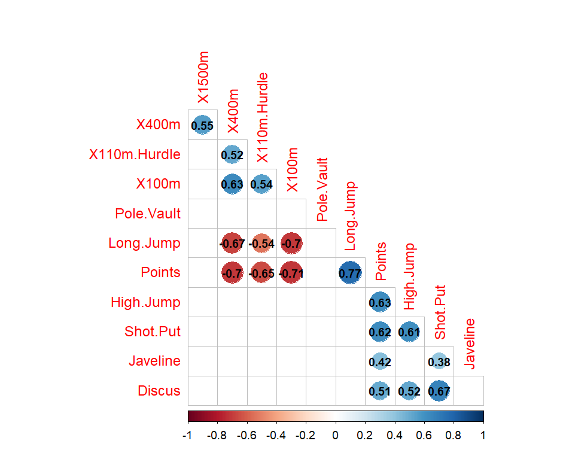

На рисунке отображаются корреляции, значимые на уровне 0.95, видно, во-первых, что многие переменные коррелируют друг с другом, Например, бег на 100 и на 400 метров), во-вторых, корреляция прыжка с шестом с результатом статистически не значима.

Можно ли говорить об именно том вкладе разных видов соревнований в результат, как утверждают авторы?

Проведем диагностику модели

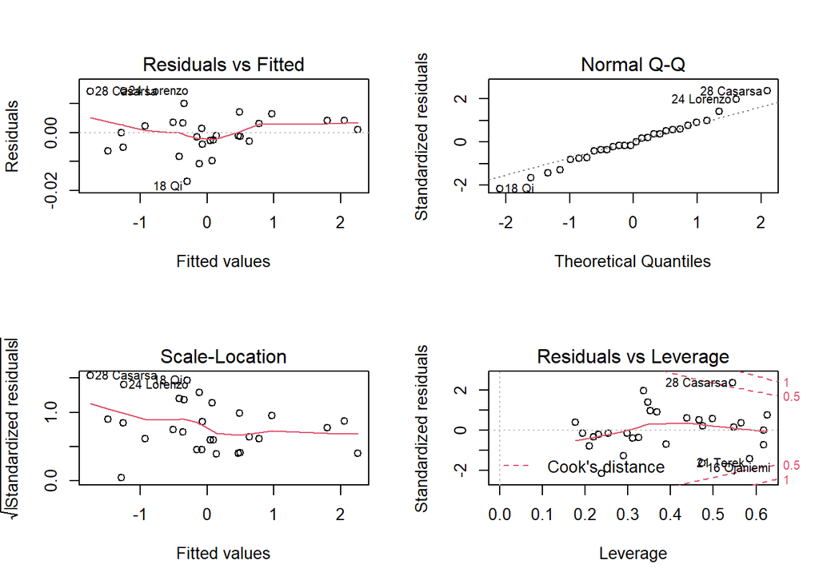

```r
par(mfrow = c(2, 2))
plot(fit)
```

```r
# par(mfrow = c(1, 1))
```

Видно, что не все остатки распределяются линейно

тест Дарбина-Уотсона. Проверяет автокорреляцию первого порядка о тесте здесь https://youtu.be/5QRbwvIbjo4 и здесь https://youtu.be/3s8Ygu0Ovss

тест дарбина-Уотсона требователен к предпосылкам

H0: нет автокорреляции

Ha: автокорреляция k-го порядка

```r
durbinWatsonTest(fit)
```

```
##  lag Autocorrelation D-W Statistic p-value
##    1      -0.1325529      2.114424    0.94
##  Alternative hypothesis: rho != 0
```

p- значение больше 0.05, поэтому мы не отвергаем гипотезу об отсутствии автокорреляции

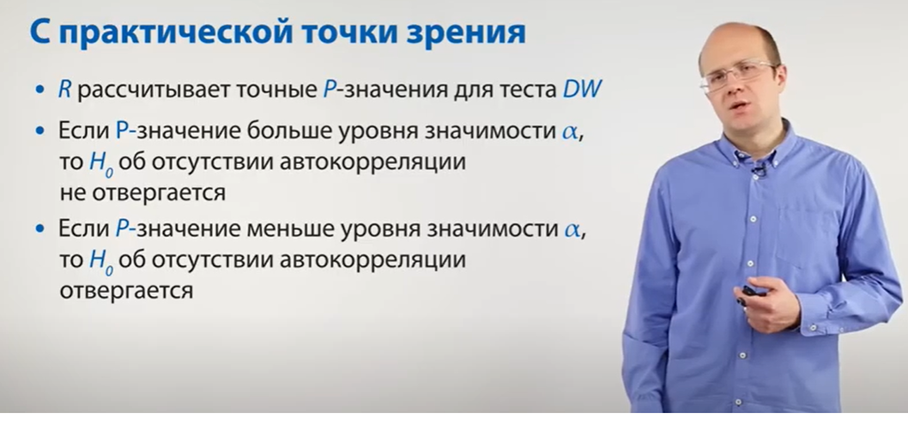

BG-тест тест Бройша-Годфри Ссылка на видео https://youtu.be/3s8Ygu0Ovss H0: нет автокорреляции Ha: автокорреляция k-го порядка

```r
bgtest(fit, order = 2)
```

```
##
##  Breusch-Godfrey test for serial correlation of order up to 2
##
## data:  fit
## LM test = 1.5284, df = 2, p-value = 0.4657
```

Вывод - автокорреляция 2-го порядка отсутствует

Component+Residual (Partial Residual) Plots

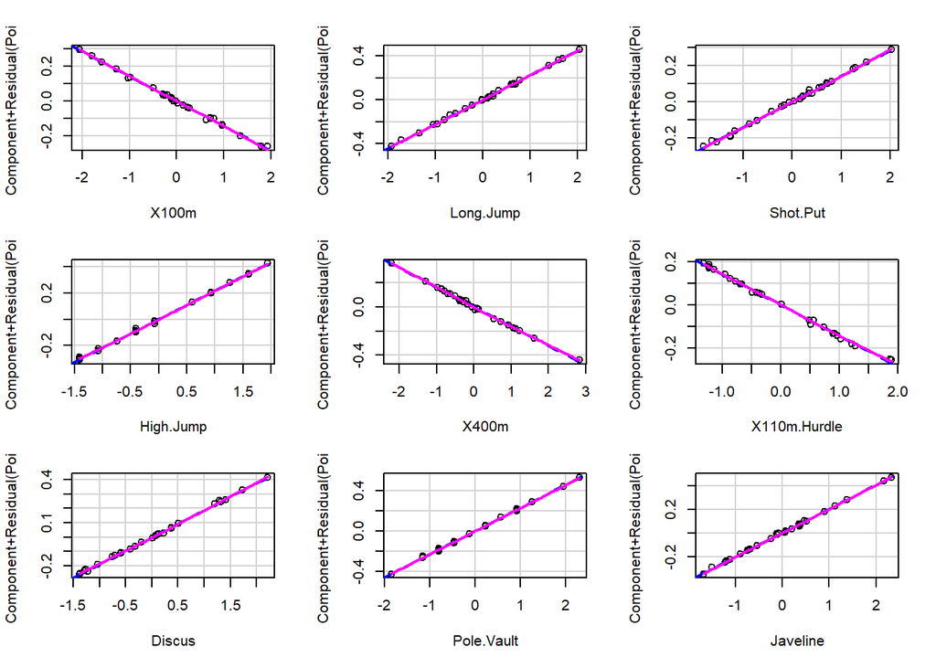

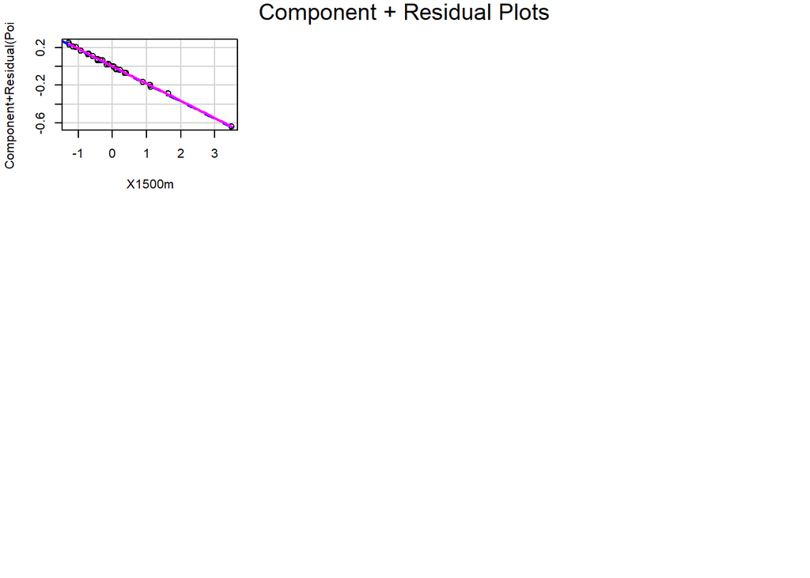

```r
crPlots(fit)
```

Интерпретация - все значения на одной линии? значит, нормальное распределение остатков?

Score Test for Non-Constant Error Variance. This test is often called the Breusch-Pagan test

```r
ncvTest(fit)
```

```
## Non-constant Variance Score Test
## Variance formula: ~ fitted.values
## Chisquare = 4.2095, Df = 1, p = 0.040198
```

p<0.05 отвергаем нулевую гипотезу о гетероскедастичности reject the null hypothesis and conclude that heteroscedasticity is present

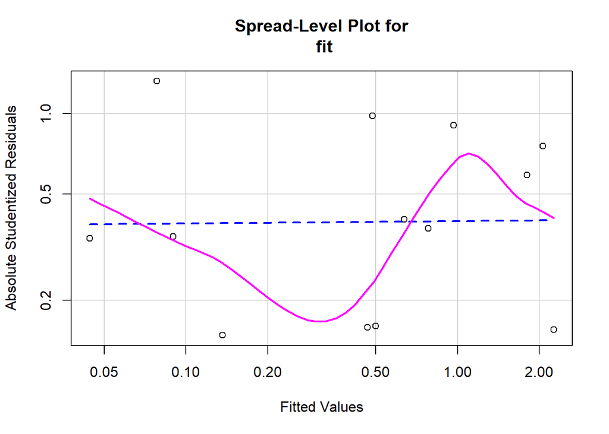

```
##
## Suggested power transformation:  0.9908924
```

```r
spreadLevelPlot(fit)
```

```r
summary(gvlma(fit))
```

```
##
## Call:
## lm(formula = Points ~ X100m + Long.Jump + Shot.Put + High.Jump +
##     X400m + X110m.Hurdle + Discus + Pole.Vault + Javeline + X1500m,
##     data = n_decathlon)
##
## Residuals:
##        Min         1Q     Median         3Q        Max
## -0.0168974 -0.0033295 -0.0005831  0.0036702  0.0144205
##
## Coefficients:
##                Estimate Std. Error t value Pr(>|t|)
## (Intercept)  -3.031e-17  1.689e-03    0.00        1
## X100m        -1.410e-01  2.936e-03  -48.03   <2e-16 ***
## Long.Jump     2.226e-01  3.199e-03   69.59   <2e-16 ***
## Shot.Put      1.414e-01  3.145e-03   44.97   <2e-16 ***
## High.Jump     2.167e-01  2.513e-03   86.24   <2e-16 ***
## X400m        -1.607e-01  3.753e-03  -42.81   <2e-16 ***
## X110m.Hurdle -1.439e-01  2.203e-03  -65.33   <2e-16 ***
## Discus        1.873e-01  2.722e-03   68.82   <2e-16 ***
## Pole.Vault    2.295e-01  2.046e-03  112.19   <2e-16 ***
## Javeline      2.016e-01  2.192e-03   91.98   <2e-16 ***
## X1500m       -1.827e-01  3.008e-03  -60.76   <2e-16 ***
## ---
## Signif. codes:  0 '***' 0.001 '**' 0.01 '*' 0.05 '.' 0.1 ' ' 1
##
## Residual standard error: 0.008938 on 17 degrees of freedom
## Multiple R-squared:  0.9999, Adjusted R-squared:  0.9999
## F-statistic: 3.38e+04 on 10 and 17 DF,  p-value: < 2.2e-16
##
##
## ASSESSMENT OF THE LINEAR MODEL ASSUMPTIONS
## USING THE GLOBAL TEST ON 4 DEGREES-OF-FREEDOM:
## Level of Significance =  0.05
##
## Call:
##  gvlma(x = fit)
##
##                        Value  p-value                   Decision
## Global Stat        13.862026 0.007749 Assumptions NOT satisfied!
## Skewness            0.003791 0.950906    Assumptions acceptable.
## Kurtosis            0.053633 0.816859    Assumptions acceptable.
## Link Function       9.457323 0.002103 Assumptions NOT satisfied!
## Heteroscedasticity  4.347279 0.037068 Assumptions NOT satisfied!
```

Вывод: Предположения НЕ удовлетворены для Global Stat, Link Function, Heteroscedasticity

Допущения приемлемые: для Skewness, Kurtosis

Variance Inflation Factors

```r
vif(fit)
```

```
##        X100m    Long.Jump     Shot.Put    High.Jump        X400m X110m.Hurdle
##     2.912598     3.458014     3.342900     2.135024     4.760487     1.640654
##       Discus   Pole.Vault     Javeline       X1500m
##     2.504250     1.414227     1.623375     3.057078
```

```r
sqrt(vif(fit))>2
```

```
##        X100m    Long.Jump     Shot.Put    High.Jump        X400m X110m.Hurdle
##        FALSE        FALSE        FALSE        FALSE         TRUE        FALSE
##       Discus   Pole.Vault     Javeline       X1500m
##        FALSE        FALSE        FALSE        FALSE
```

Вывод: VIF для бега на 400 метров больше 4-х

Bonferroni Outlier Test

```r
outlierTest(fit)
```

```
## No Studentized residuals with Bonferroni p < 0.05
## Largest |rstudent|:
##            rstudent unadjusted p-value Bonferroni p
## 28 Casarsa 2.802608           0.012772      0.35763
```

```r
gqtest(fit)
```

```
##
##  Goldfeld-Quandt test
##
## data:  fit
## GQ = 2.9305, df1 = 3, df2 = 3, p-value = 0.2004
## alternative hypothesis: variance increases from segment 1 to 2
```

## Итоговые выводы

С помощью тестов на диагностику модели получены противоречивые результаты. Хотя пример вдохновляет, непонятно, можно ли следовать такой схеме для выявления влияния отдельных компонентов на общий результат в спорте. Непонятно, действительно ли коэффициенты b1 отличаются между собой. Действительно ли какие-то виды соревнования вносят больший вклад в итоговый результат? теоретически это возможно, но достаточно ли тут математических аргументов?

Почему отсутствует автокорреляция по тестам, когда просто при составлении матрицы корреляции не маленькие и статистически значимые?

Дальше авторы статьи находят такой показатель как “наименьшая стоимость изменений” (smallest worthwile change (SWC)), умножая стандартное отклонение итоговых очков за каждую дисциплину на 0.2, и находят отношение этой величины к кофээфициентам модели. Получается практически идентичная первому графику картина - сложнее всего улучшить бег на 100 метров, затем толкание ядра и так далее, и, проще всего улучшить результат в прыжке с шестом.

По сути, чем меньше стандартное отклонение, тем выше конкуренция и сложнее улучшить результат. Я не знаю, нужны ли вообще эти “smallest worthwile change” очки.

Далее авторы строят профили спортсменов по успешности выступления в разных дисциплинах.